# Three Pointers and Their Effect on the NBA

# Analysis

### Data Cleanup

After cleaning, the first several rows of our data set look like this:

```
##    season  fgm  fga fg_pct thrpt_m thrpt_a thrpt_pct twopt_m twopt_a twopt_pct
## 1 2022-23 3460 7278  0.475    1315    3492     0.377    2145    3786     0.567
## 2 2021-22 3341 7167  0.466    1085    3044     0.356    2256    4123     0.547
## 3 2020-21 2985 6401  0.466     979    2618     0.374    2006    3783     0.530
## 4 2019-20 2971 6448  0.461     905    2487     0.364    2066    3961     0.522
## 5 2018-19 3451 7423  0.465    1032    2829     0.365    2419    4594     0.527
## 6 2017-18 3141 6975  0.450     939    2492     0.377    2202    4483     0.491
##    pts
## 1 9671
## 2 9164
## 3 8109
## 4 8183
## 5 9216
## 6 8529
```

### Data Summaries

A summary of the following averages: volume (quantity) of shot attempts, the respective percentages of those attempts, and points scored across all seasons in the data set.

```
##    avg_fga avg_fg_pct avg_2pt_a avg_2pt_pct avg_3pt_a avg_3pt_pct  avg_pts
## 1 6770.575    0.47035  5446.575    0.499475      1324       0.336 8387.775
```

Data for the 20 most recent seasons (the first half):

```
##   avg_fga avg_fg_pct avg_2pt_a avg_2pt_pct avg_3pt_a avg_3pt_pct avg_pts
## 1 6623.05     0.4615    4679.6      0.5048   1943.45     0.36035  8252.8
```

Data for the 20 seasons before that (the second half):

```
##   avg_fga avg_fg_pct avg_2pt_a avg_2pt_pct avg_3pt_a avg_3pt_pct avg_pts
## 1  6918.1     0.4792   6213.55     0.49415    704.55     0.31165 8522.75
```

### Data Analysis

#### Three-Point Study

Here, we investigate the numbers behind the three-point shot of the Celtics. Specifically, we look at the volume of three point shots taken over the season and also look at the accuracy of the shot.

Both give an implied understanding that, for the same shot, if the volume has increased and the accuracy has also increased, it is assumed to be more integral to the overall team offense and therefore more plays are built around the three point shot rather than the average mid-range shot.

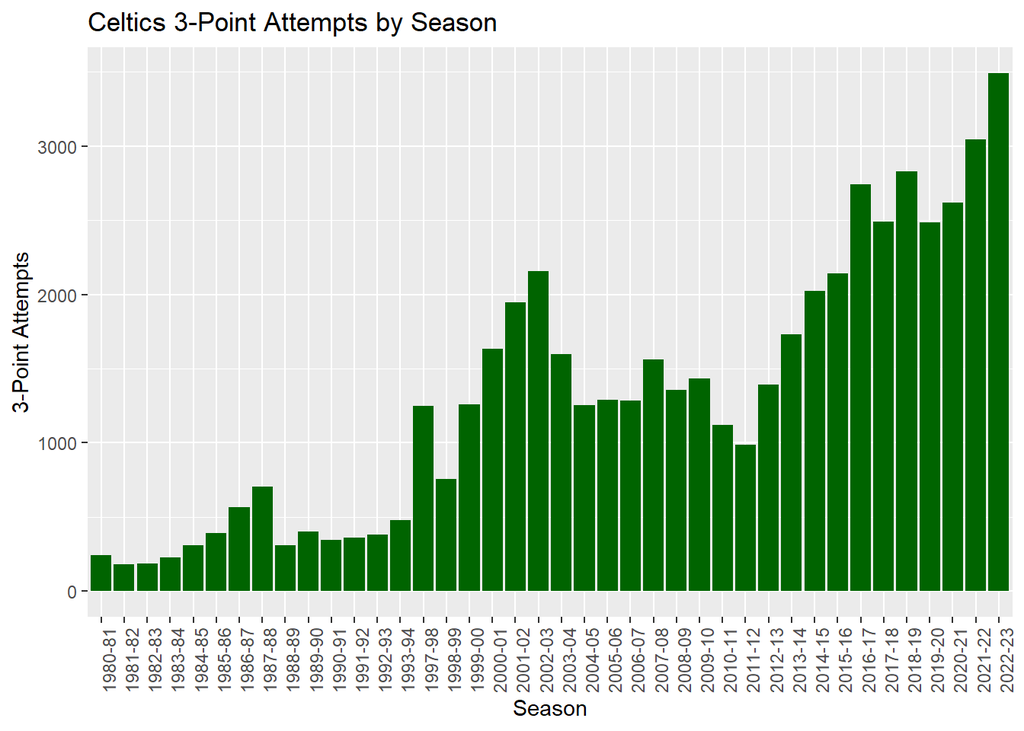

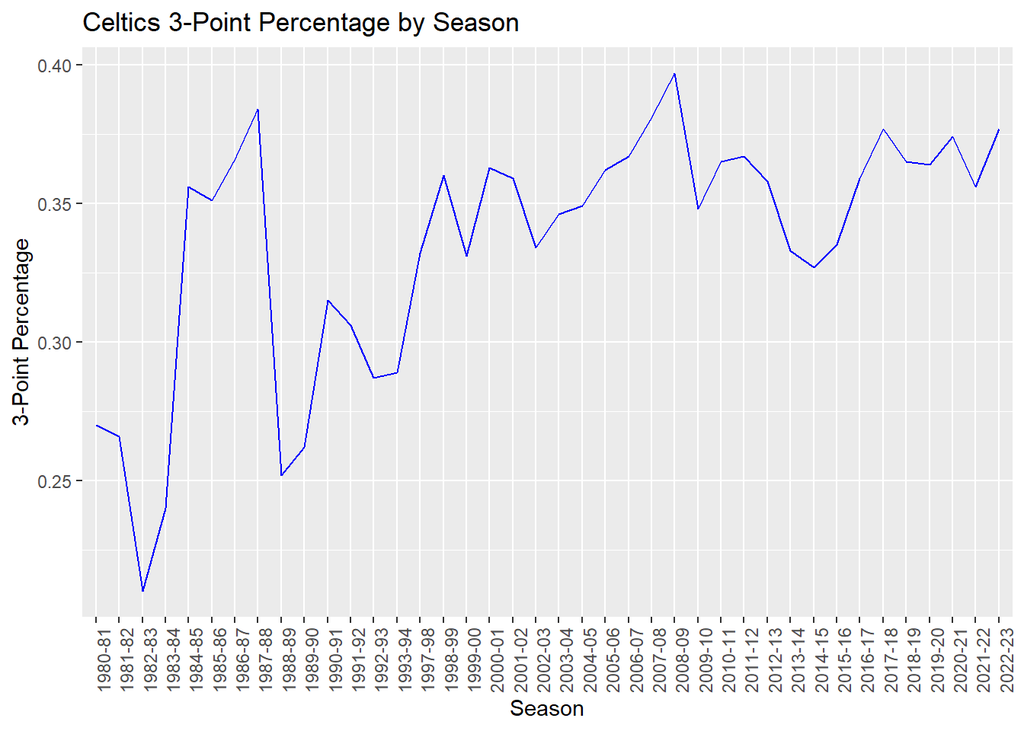